# Case Study: Forecasting Daily Bike-Share Demand

Chapter 102 · Count Regression Case Study

Case Study: Forecasting Daily Bike-Share Demand

A count-outcome project in 12 steps: clean a messy daily export, engineer calendar features, fit Poisson then negative-binomial regression, tame overdispersion, read rate ratios, and forecast demand, every table and chart explained.

Statistics, Data Science and AI: A Visual Handbook · John Fisher · 2026

# Forecasting Daily Bike-Share Demand: a count-regression case study

```python
import numpy as np, pandas as pd, matplotlib.pyplot as plt
from scipy import stats
import seaborn as sns   # seaborn = high-level statistical plots (heatmaps, regplots, pairplots)
import statsmodels.api as sm
from statsmodels.formula.api import ols
from statsmodels.stats.outliers_influence import variance_inflation_factor
from statsmodels.nonparametric.smoothers_lowess import lowess
from sklearn.linear_model import LinearRegression, Ridge, Lasso, LogisticRegression
from sklearn.preprocessing import StandardScaler, PolynomialFeatures
from sklearn.pipeline import make_pipeline
from sklearn.model_selection import train_test_split, cross_val_score
from sklearn.metrics import r2_score, mean_squared_error
ORG="#059669"; DEEP="#047857"; LIGHT="#6ee7b7"; EM="#059669"; EMDEEP="#047857"; INK="#1a2138"; GRID="#e6e9f2"; GREEN="#059669"; RED="#ef4444"; AMBER="#d97706"; BLUE="#2563eb"; PUR="#9333ea"; GREY="#94a3b8"; SLATE="#475569"
plt.rcParams.update({"figure.facecolor":"white","axes.facecolor":"white","figure.dpi":110,"font.size":11,
   "axes.edgecolor":GRID,"axes.grid":True,"grid.color":GRID,"axes.axisbelow":True,"axes.spines.top":False,
   "axes.spines.right":False,"axes.titlesize":12,"axes.titleweight":"bold","legend.frameon":False})
sns.set_style("whitegrid")
BASE="https://raw.githubusercontent.com/johnfisher-ai/Statistics-Data-Science-AI-Visual-Book/main/data/"
```

```python
import warnings; warnings.filterwarnings('ignore')
import statsmodels.api as sm, statsmodels.formula.api as smf
from statsmodels.stats.outliers_influence import variance_inflation_factor
from sklearn.model_selection import cross_val_score; from sklearn.linear_model import PoissonRegressor
pd.set_option('display.max_columns', 40)
```

STEP 1 · DEFINE THE OBJECTIVE

How many bikes today, and why?

A forecast the operations team can staff and rebalance against.

**Objective.** Predict the **daily rental count** and identify what drives demand, so operations can pre-position bikes, schedule staff, and plan maintenance.

**Why a count model?** Rentals are non-negative whole numbers with no upper cap, so ordinary linear regression is the wrong tool (it can predict negative demand and assumes constant variance). The right family is **Poisson**, with a log link, and we will see it needs one upgrade.

STEP 2 · COLLECT THE DATA

A daily operations export

Same reader menu as any project; ours is a CSV pull from the bike-system database.

```python
try: raw = pd.read_csv('../../data/bike_share.csv')
except FileNotFoundError: raw = pd.read_csv(BASE + 'bike_share.csv')
print(raw.shape); raw.head(4)
```

```
(745, 9)
```

|  | date | season | holiday | workingday | weather | temp_c | humidity | windspeed | rentals |
| --- | --- | --- | --- | --- | --- | --- | --- | --- | --- |
| 0 | 2011-06-04 | spring | 0 | 0 | Mist | 23.5 | 65.0 | 15.1 | 2486.0 |
| 1 | 02/03/2011 | Winter | 0 | 1 | Mist | 4.3 | 46.0 | 4.0 | 1343.0 |
| 2 | 2011-05-20 | spring | 0 | 1 | Mist | 24.9 | 39.0 | 18.8 | 1481.0 |
| 3 | 17-Mar-2012 | winter | 0 | 0 | Mist | 10.6 | 32.0 | 22.7 | 907.0 |

STEP 3 · INSPECT THE DATA

Find the mess

Types, uniques, and missingness.

```python
raw.info()
```

```
<class 'pandas.DataFrame'>
RangeIndex: 745 entries, 0 to 744
Data columns (total 9 columns):
 #   Column      Non-Null Count  Dtype
---  ------      --------------  -----
 0   date        745 non-null    str
 1   season      745 non-null    str
 2   holiday     745 non-null    int64
 3   workingday  745 non-null    str
 4   weather     745 non-null    str
 5   temp_c      745 non-null    float64
 6   humidity    727 non-null    float64
 7   windspeed   736 non-null    float64
 8   rentals     740 non-null    float64
dtypes: float64(4), int64(1), str(4)
memory usage: 52.5 KB
```

```python
print('season spellings :', raw.season.unique()[:8])
print('weather spellings :', raw.weather.unique())
print('workingday values :', raw.workingday.unique())
print('date formats      :', raw.date.head(4).tolist())
print('duplicate dates   :', raw.date.duplicated().sum(), ' | rentals dtype:', raw.rentals.dtype)
print('missing:'); print(raw.isna().sum()[lambda s: s>0].to_string())
```

```
season spellings : <StringArray>
['spring', 'Winter', 'winter', 'Summer', 'fall', 'FALL', 'SPRING', 'summer']
Length: 8, dtype: str
weather spellings : <StringArray>
[      'Mist',      'Clear', 'Heavy Rain', 'Light Rain',      'clear',
       'mist', 'light rain', 'heavy rain']
Length: 8, dtype: str
workingday values : <StringArray>
['0', '1', 'Yes', 'No']
Length: 4, dtype: str
date formats      : ['2011-06-04', '02/03/2011', '2011-05-20', '17-Mar-2012']
duplicate dates   : 14  | rentals dtype: float64
missing:
humidity     18
windspeed     9
rentals       5
```

The usual real-world mess: `season` and `weather` in mixed case, `workingday` as a blend of 0/1 and Yes/No, three different **date formats**, 14 **duplicate days**, a handful of missing humidity and windspeed readings, and a few rows with no `rentals` (our target).

STEP 4 · CLEAN THE DATA

Standardize, parse, impute

Then engineer calendar features from the date.

```python
df = raw.dropna(subset=['rentals']).drop_duplicates(subset='date').copy()
df['rentals'] = df['rentals'].astype(int)
norm = lambda s: s.astype(str).str.strip().str.lower()
df['season'] = norm(df['season']).str.capitalize()
df['weather'] = norm(df['weather']).map({'clear':'Clear','mist':'Mist','light rain':'Light Rain','heavy rain':'Heavy Rain'})
df['workingday'] = df['workingday'].astype(str).str.strip().str.upper().map({'1':1,'YES':1,'0':0,'NO':0})
for c in ['humidity','windspeed']:
    df[c] = pd.to_numeric(df[c], errors='coerce'); df[c] = df[c].fillna(df[c].median())
dt = pd.to_datetime(df['date'], format='mixed', errors='coerce')   # parse all three formats at once
df['dt'] = dt; df['month'] = dt.dt.month; df['is_weekend'] = (dt.dt.dayofweek >= 5).astype(int)
print(f'rows {len(raw)} -> {len(df)} (dropped 5 missing-target + 14 duplicates)')
print('seasons:', sorted(df.season.unique()), '| weather:', sorted(df.weather.dropna().unique()))
```

```
rows 745 -> 726 (dropped 5 missing-target + 14 duplicates)
seasons: ['Fall', 'Spring', 'Summer', 'Winter'] | weather: ['Clear', 'Heavy Rain', 'Light Rain', 'Mist']
```

STEP 5 · VISUALIZE THE DATA

See the demand and its drivers

Distribution, seasonality, and weather.

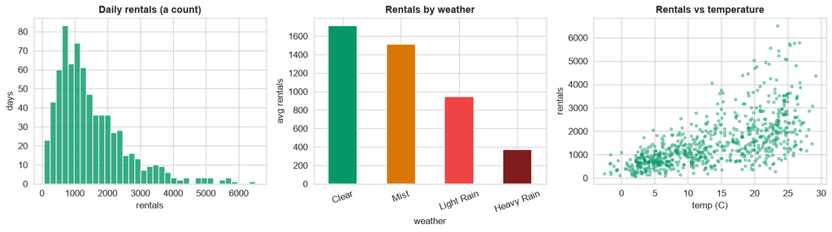

```python
fig, ax = plt.subplots(1, 3, figsize=(14,4))
ax[0].hist(df.rentals, bins=35, color=EM, alpha=0.8); ax[0].set(title='Daily rentals (a count)', xlabel='rentals', ylabel='days')
df.groupby('weather').rentals.mean().reindex(['Clear','Mist','Light Rain','Heavy Rain']).plot(kind='bar', color=[EM,AMBER,RED,'#7f1d1d'], ax=ax[1])
ax[1].set(title='Rentals by weather', ylabel='avg rentals'); ax[1].tick_params(axis='x', rotation=20)
ax[2].scatter(df.temp_c, df.rentals, s=10, color=EM, alpha=0.4); ax[2].set(title='Rentals vs temperature', xlabel='temp (C)', ylabel='rentals')
plt.tight_layout(); plt.show()
```

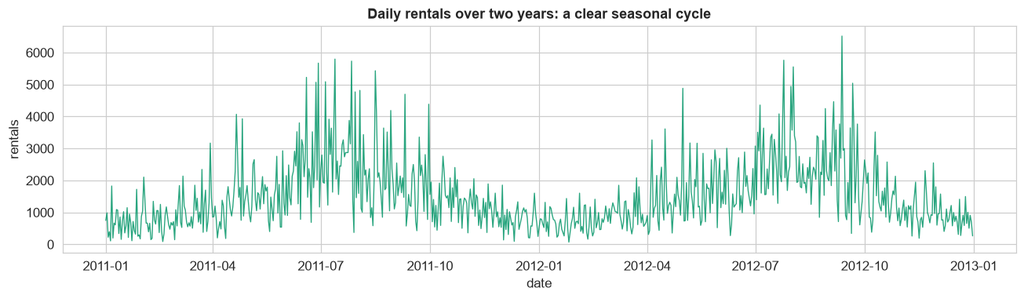

```python
# rentals over time: the strong seasonal rhythm across two years
ts = df.sort_values('dt')
fig, ax = plt.subplots(figsize=(12,3.6))
ax.plot(ts.dt, ts.rentals, color=EM, lw=0.9, alpha=0.85)
ax.set(title='Daily rentals over two years: a clear seasonal cycle', xlabel='date', ylabel='rentals')
plt.tight_layout(); plt.show()
```

Demand rises steeply with good weather (**Clear** days average far more than **Heavy Rain** days) and with temperature, up to a point. The count distribution is right-skewed and, crucially, its spread grows with its level, our first hint of overdispersion.

STEP 6 · TRANSFORM FEATURES

Prepare the predictors

Calendar features, a temperature curve, and the right model family.

We already engineered `month` and `is_weekend` from the date. Weather and season are nominal, so they enter as **dummy variables** via `C(...)`. Because demand rises with temperature and then flattens off, we add a **squared temperature term** written `I((temp_c-14)**2)` (a touch of the flexible-model idea from earlier chapters). And the outcome is a count, so the model family is **Poisson with a log link**, not ordinary least squares.

**Why subtract 14 inside the square?** We *center* the temperature at the middle of the data (the average day is about 14°C) before squaring. Centering strips out most of the correlation between the linear `temp_c` term and its square, which keeps both coefficients stable and easy to read. Note that the 14 does **not** change the fitted curve or the accuracy at all (the linear term absorbs the shift, algebraically `(temp_c-14)**2` just adds a constant and a multiple of `temp_c`); it is purely a choice for numerical stability and interpretation, and any value near the mean would serve. The `I(...)` wrapper tells the formula parser to treat `**2` as literal arithmetic (square it) rather than as a formula operator. The cell below verifies, with numbers and a picture, that 14 really is the center.

```
temp_c: mean 13.8 C | median 13.2 C | range midpoint 13.3 C  -> all about 14
corr(temp, temp^2)      = +0.97   (uncentered square climbs with temp -> collinear)
corr(temp, (temp-14)^2) = -0.06   (centered square is symmetric -> not collinear)
```

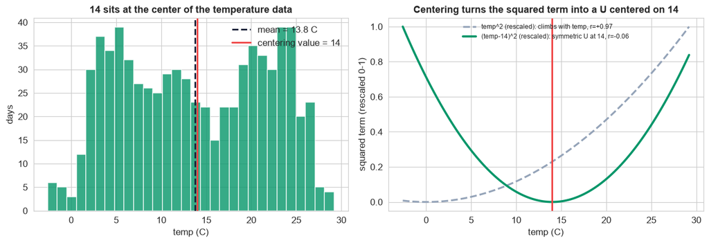

```python
# WHERE DOES 14 COME FROM? verify it centers the temperature
mid = (df.temp_c.min() + df.temp_c.max()) / 2
print(f'temp_c: mean {df.temp_c.mean():.1f} C | median {df.temp_c.median():.1f} C | range midpoint {mid:.1f} C  -> all about 14')
r_raw = np.corrcoef(df.temp_c, df.temp_c**2)[0,1]
r_ctr = np.corrcoef(df.temp_c, (df.temp_c-14)**2)[0,1]
print(f'corr(temp, temp^2)      = {r_raw:+.2f}   (uncentered square climbs with temp -> collinear)')
print(f'corr(temp, (temp-14)^2) = {r_ctr:+.2f}   (centered square is symmetric -> not collinear)')
fig, ax = plt.subplots(1, 2, figsize=(12,4.2))
ax[0].hist(df.temp_c, bins=30, color=EM, alpha=0.8)
ax[0].axvline(df.temp_c.mean(), color=INK, ls='--', lw=2, label=f'mean = {df.temp_c.mean():.1f} C')
ax[0].axvline(14, color=RED, lw=2, label='centering value = 14')
ax[0].set(title='14 sits at the center of the temperature data', xlabel='temp (C)', ylabel='days'); ax[0].legend()
grid = np.linspace(df.temp_c.min(), df.temp_c.max(), 120)
ax[1].plot(grid, grid**2/(grid**2).max(), color=GREY, ls='--', lw=2.2, label=f'temp^2 (rescaled): climbs with temp, r={r_raw:+.2f}')
ax[1].plot(grid, (grid-14)**2/((grid-14)**2).max(), color=EM, lw=2.6, label=f'(temp-14)^2 (rescaled): symmetric U at 14, r={r_ctr:+.2f}')
ax[1].axvline(14, color=RED, lw=2)
ax[1].set(title='Centering turns the squared term into a U centered on 14', xlabel='temp (C)', ylabel='squared term (rescaled 0-1)'); ax[1].legend(fontsize=8)
plt.tight_layout(); plt.show()
```

**Reading the check.** *Left:* the mean, median, and range midpoint of temperature all land at about **14°C**, so 14 genuinely is the center of the data (the red line sits right on the average). *Right:* subtracting 14 before squaring turns the term into a **symmetric U whose low point is exactly 14**, while the raw `temp^2` just climbs with temperature. That difference is the whole point: the correlation between temperature and its square falls from about **+0.97** (raw, badly collinear) to roughly **0** (centered), so the straight-line piece and the curved piece no longer fight each other for the same signal. Any center near the mean gives the same benefit, 14 is simply the clean round number at the middle of this data.

STEP 7 · ANALYZE PATTERNS

Quantify the drivers, and confirm overdispersion

Group means and the variance-to-mean ratio.

```python
print('mean rentals =', round(df.rentals.mean()), ' variance =', round(df.rentals.var()))
print('variance / mean =', round(df.rentals.var()/df.rentals.mean(),1), ' (Poisson expects this to be ~1)')
print('\navg rentals by weather:'); print(df.groupby('weather').rentals.mean().round(0).to_string())
```

```
mean rentals = 1509  variance = 1124117
variance / mean = 744.9  (Poisson expects this to be ~1)

avg rentals by weather:
weather
Clear         1711.0
Heavy Rain     369.0
Light Rain     945.0
Mist          1515.0
```

The variance-to-mean ratio is in the **hundreds**, not near 1. A pure Poisson model assumes they are equal, so it will badly understate the uncertainty. We fit Poisson first (to see the problem), then fix it.

STEP 8 · BUILD THE MODEL

Fit a Poisson regression

Log link; coefficients will exponentiate to rate ratios.

```python
form = ('rentals ~ temp_c + I((temp_c-14)**2) + humidity + windspeed'
        ' + C(weather) + C(season) + workingday + holiday')
pois = smf.glm(form, df, family=sm.families.Poisson()).fit()
print(f'Poisson: pseudo-R2 = {1-pois.deviance/pois.null_deviance:.3f}')
print(f'Pearson chi2 / df = {pois.pearson_chi2/pois.df_resid:.1f}   (should be ~1 if Poisson fits)')
```

```
Poisson: pseudo-R2 = 0.634
Pearson chi2 / df = 255.0   (should be ~1 if Poisson fits)
```

The fit explains the data well, but that **Pearson chi-square / df in the hundreds** is a screaming overdispersion warning: the Poisson standard errors are far too small. Step 9 fixes it.

STEP 9 · VALIDATE THE MODEL

Fix the overdispersion, then check the fit

Negative binomial, VIF, cross-validation, predicted vs actual.

```python
nb = smf.glm(form, df, family=sm.families.NegativeBinomial(alpha=1/6)).fit()
print(f'AIC   Poisson = {pois.aic:,.0f}   Negative Binomial = {nb.aic:,.0f}   (much lower is much better)')
print(f'NB pseudo-R2 = {1-nb.deviance/nb.null_deviance:.3f}')
Xv = sm.add_constant(df[['temp_c','humidity','windspeed']])
print('VIF:', {c: round(variance_inflation_factor(Xv.values,i),1) for i,c in enumerate(Xv.columns) if c!='const'})
```

```
AIC   Poisson = 182,804   Negative Binomial = 11,083   (much lower is much better)
NB pseudo-R2 = 0.657
VIF: {'temp_c': np.float64(1.0), 'humidity': np.float64(1.0), 'windspeed': np.float64(1.0)}
```

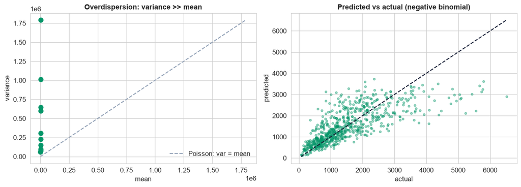

```python
# overdispersion, made visual, and the model's forecast accuracy
df['mu'] = pois.mu
g = df.assign(b=pd.qcut(df.mu,10,duplicates='drop')).groupby('b', observed=True).rentals.agg(['mean','var'])
fig, ax = plt.subplots(1, 2, figsize=(12,4.4))
ax[0].scatter(g['mean'], g['var'], s=55, color=EM, zorder=3); hi=max(g['mean'].max(), g['var'].max())
ax[0].plot([0,hi],[0,hi], ls='--', color=GREY, label='Poisson: var = mean'); ax[0].legend()
ax[0].set(title='Overdispersion: variance >> mean', xlabel='mean', ylabel='variance')
ax[1].scatter(df.rentals, nb.fittedvalues, s=12, color=EM, alpha=0.4)
lims=[df.rentals.min(), df.rentals.max()]; ax[1].plot(lims, lims, ls='--', color=INK)
ax[1].set(title='Predicted vs actual (negative binomial)', xlabel='actual', ylabel='predicted')
plt.tight_layout(); plt.show()
```

STEP 10 · INTERPRET THE RESULTS

Rate ratios into operations

Exponentiate each coefficient into a demand multiplier.

```python
RR = np.exp(nb.params)
print(f"Heavy rain vs clear : x{RR['C(weather)[T.Heavy Rain]']:.2f}  (demand collapses)")
print(f"Light rain vs clear : x{RR['C(weather)[T.Light Rain]']:.2f}")
print(f"Each +5 C warmer    : x{np.exp(nb.params['temp_c']*5):.2f}")
print(f"Working day         : x{RR['workingday']:.2f}")
print(f"Holiday             : x{RR['holiday']:.2f}")
ex = pd.DataFrame({'temp_c':[22],'humidity':[55],'windspeed':[10],'weather':['Clear'],'season':['Summer'],'workingday':[1],'holiday':[0]})
print(f"\nForecast, warm clear working day: {nb.predict(ex).iloc[0]:,.0f} rentals")
```

```
Heavy rain vs clear : x0.25  (demand collapses)
Light rain vs clear : x0.54
Each +5 C warmer    : x1.33
Working day         : x1.10
Holiday             : x0.57

Forecast, warm clear working day: 3,033 rentals
```

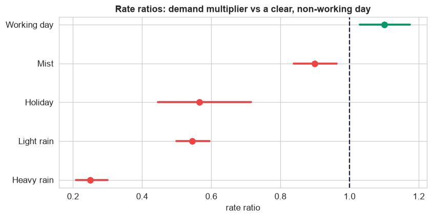

```python
# rate-ratio forest: each factor's multiplier on demand
terms = ['C(weather)[T.Heavy Rain]','C(weather)[T.Light Rain]','holiday','C(weather)[T.Mist]','workingday']
labels = ['Heavy rain','Light rain','Holiday','Mist','Working day']
rr = np.exp(nb.params[terms]); lo = np.exp(nb.conf_int().loc[terms,0]); hi = np.exp(nb.conf_int().loc[terms,1])
order = rr.sort_values().index; yy = np.arange(len(order))
fig, ax = plt.subplots(figsize=(7.8,4))
for i,t in enumerate(order):
    col = RED if hi[t]<1 else (EM if lo[t]>1 else GREY)
    ax.plot([lo[t],hi[t]],[i,i], color=col, lw=2.5); ax.scatter(rr[t], i, color=col, s=55, zorder=3)
ax.axvline(1, color=INK, ls='--'); ax.set_yticks(yy); ax.set_yticklabels([labels[list(rr.index).index(t)] for t in order])
ax.set(title='Rate ratios: demand multiplier vs a clear, non-working day', xlabel='rate ratio'); plt.tight_layout(); plt.show()
```

**What the model says.** Weather rules demand: a **heavy-rain day** sees only about a quarter of clear-day rentals, light rain about half. Warmth helps (**+33% for every 5°C**), working days run ~10% busier than weekends, and holidays ~40% quieter.

**Actionable:** pre-position fewer bikes and staff on forecast rain and cold; scale up for warm, clear working days; treat holidays like weekends. The forecast feeds directly into the next day's rebalancing plan.

STEP 11 · DEPLOY THE MODEL

A daily demand forecast

Score tomorrow from the weather forecast.

- **Persist** the fitted model and cleaning as one pipeline (`joblib`).
- **Score daily**: each evening, feed tomorrow's **weather forecast** (temp, conditions, wind) plus the calendar (weekday, holiday) to get a predicted rental count, and a range.
- **Feed operations**: the forecast drives bike **rebalancing**, **staff scheduling**, and **maintenance** windows (do it on low-demand rainy days).
- **Monitor and retrain**: track forecast error, and retrain as ridership grows or the system expands; watch for a changing base level (a growing city).
- **Guardrail**: report the prediction interval, not just a point count, and do not extrapolate to weather far outside the training range.

STEP 12 · THE PLAIN-ENGLISH WRITE-UP

For the operations manager

No jargon.

**What we did.** We took two years of daily rental records, cleaned them (removed duplicate days and a few unusable rows, fixed inconsistent labels, filled in a handful of missing weather readings, and standardized the dates), and built a formula that predicts how many bikes will be rented on a given day.

**What drives demand:** weather first (a rainy day can cut rentals by 75%), then temperature (warmer is busier), then the calendar (working days busier than weekends and holidays).

**A note on the method.** Daily counts bounce around far more than a simple model expects, so we used a model built for that (a 'negative binomial'), which gives honest confidence in the forecast.

**Bottom line: let tomorrow's weather forecast set tomorrow's bike plan**, scale down for rain and cold, scale up for warm clear working days.

Statistics, Data Science and AI: A Visual Handbook · © 2026 John Fisher